# 04 – Rerun MIIC on the authors’ input (case study 2)

Same input files, same settings: do we get the same network?

Author

Minh Le, Jeanne Leclerc

Published

October 13, 2026

## Goal

Notebook 02 showed that running `miic` ourselves on the authors’ case study 1 files gives exactly the network of the web server. Here we do the same test for case study 2, which is larger (238 variables, 7,563 cells, three cell types) and contains discrete metadata variables.

The same three sources of difference as in notebook 02 apply: code version (our `miic` commit is two days younger than the server run of 21 January 2025), randomness of the confidence filter, and number of threads. The server used **one thread** here, and so do we.

**Inputs:** the authors’ files in `data/case2/causalccc_server_w0788tM1wzXGHLzNaKKa/` (read only). **Outputs:** `results/case2/04_rerun_miic/`: the full MIIC result (`miic_result.rds`) and our edge list (`edges_rerun.tsv`).

**NoteRunning time**

The server needed about three hours. The notebook saves the result the first time and reloads it afterwards. To force a new run, delete `results/case2/04_rerun_miic/miic_result.rds`.

## Setup

```r
library(tidyverse)
library(miic)
root <- getwd()
while (!file.exists(file.path(root, "scripts", "helpers.R"))) {
  if (dirname(root) == root) stop("Repository root not found. Open the repository folder in Positron.")
  root <- dirname(root)
}
source(file.path(root, "scripts", "helpers.R"))

job_dir     <- file.path(root, "data", "case2", "causalccc_server_w0788tM1wzXGHLzNaKKa")
results_dir <- file.path(root, "results", "case2", "04_rerun_miic")

if (!dir.exists(job_dir)) stop("Data not found: run scripts/case2/download_case2.sh first.")
dir.create(results_dir, recursive = TRUE, showWarnings = FALSE)

packageVersion("miic")
```

```
[1] '2.0.3'
```

## 1. Read the inputs

As in notebook 03, `guess_max = Inf` makes sure the metadata columns are read as text. The cell type of each row and of each column is found as in notebook 03.

```r
mosaic      <- read_tsv(file.path(job_dir, "input.tsv"), guess_max = Inf, show_col_types = FALSE)
state_order <- read_tsv(file.path(job_dir, "clean_state_order.tsv"), show_col_types = FALSE)
lr_pairs    <- read_tsv(file.path(job_dir, "clean_interact_edges.tsv"),
                        col_names = c("ligand", "receptor"), show_col_types = FALSE)

edges_authors <- read_tsv(file.path(job_dir, "edgesList.miic.summary.txt"), show_col_types = FALSE)

row_type <- case_when(!is.na(mosaic$labels_Fibroblasts) ~ "Fibroblasts",
                      !is.na(mosaic$labels_T_cell)      ~ "T_cell",
                      !is.na(mosaic$labels_DCs)         ~ "DCs")
col_type <- column_cell_type(mosaic, row_type)
```

Unlike case study 1, the server kept only one version of the result (there is no `_save` file).

## 2. Discrete or continuous?

Notebook 02 found that the `causalCCC` package declares a variable discrete when it has 5 or fewer distinct values, counting `NA` as a value. Does the state order of case study 2 follow the same rule?

```r
distinct_with_na <- map_int(mosaic, n_distinct)

tibble(variable = names(mosaic), distinct_with_na, is_text = map_lgl(mosaic, is.character)) |>
  left_join(select(state_order, variable = var_names, var_type), by = "variable") |>
  count(var_type, is_text, five_or_fewer = distinct_with_na <= 5)
```

```
# A tibble: 2 × 4
  var_type is_text five_or_fewer     n
     <dbl> <lgl>   <lgl>         <int>
1        0 TRUE    TRUE              6
2        1 FALSE   FALSE           232
```

Here only the six text metadata are discrete, and no gene has 5 values or fewer, so the rule makes no difference. It is a close call, though: the sparsest genes have 6 values counting `NA`.

```r
sort(distinct_with_na[state_order$var_names[state_order$var_type == 1]]) |> head(4)
```

```
     CAMSAP2 TNFRSF14_DCs   LGALS9_DCs    ITGAX_DCs
           6            6            7            7
```

## 3. Run MIIC (or reload the saved result)

The same call as in notebook 02, except `n_threads = 1` to match the server.

The settings are those of the CausalCCC web server (file `script.sh` of the job), **not** the defaults of `miic()`. The table lists all of them next to the defaults of the `miic` version we use (2.0.3). Most are the same; the three in bold are the ones that differ.

| Server option (`script.sh`) | `miic()` argument | Server value | `miic()` default |
| --- | --- | --- | --- |
| `--complexity` | `cplx` | `nml` | `nml` |
| `--orientation` | `orientation` | `TRUE` | `TRUE` |
| `--latent_variables` | `latent` | `orientation` | `orientation` |
| `--test_MAR` | `test_mar` | `TRUE` | `TRUE` |
| `--consistency` | `consistent` | `no` | `no` |
| `--eff_n` | `n_eff` | `-1` | `-1` |
| `--negative_info` | `negative_info` | `no` | `FALSE` |
| `--consensus_threshold` | `consensus_threshold` | `0.8` | `0.8` |
| `--max_iteration` | `max_iteration` | `100` | `100` |
| `--n_threads` | `n_threads` | `1` | `1` |
| **`--orient_probab_ratio`** | **`ori_proba_ratio`** | **`0.01`** | **`1`** |
| **`--conf_shuffle`** | **`n_shuffles`** | **`100`** | **`0`** |
| **`--conf_ratio`** | **`conf_threshold`** | **`0.01`** | **`0`** |

The three differences:

- **`n_shuffles = 100`**: the server computes a *confidence ratio* for each link by shuffling the data 100 times; `miic` does not by default.
- **`conf_threshold = 0.01`**: links whose confidence ratio is above 0.01 are discarded; by default no link is filtered this way.
- **`ori_proba_ratio = 0.01`**: the threshold on the orientation probabilities is much lower than the default.

These three settings change which links are kept and how they are oriented, so they must be copied to reproduce the authors’ network. In addition, the 43 L-R pairs are given as `interact_edges` (links imposed in the network). The script sets no random seed: we use `set.seed(2026)`, which only affects the shuffles.

```r
result_file <- file.path(results_dir, "miic_result.rds")

if (file.exists(result_file)) {
  miic_result <- readRDS(result_file)
  message("Loaded the saved result from ", result_file)
} else {
  set.seed(2026)
  start <- Sys.time()
  miic_result <- miic(
    input_data      = as.data.frame(mosaic),
    state_order     = as.data.frame(state_order),
    interact_edges  = as.data.frame(lr_pairs),
    cplx            = "nml",
    orientation     = TRUE,
    latent          = "orientation",
    ori_proba_ratio = 0.01,
    n_shuffles      = 100,
    conf_threshold  = 0.01,
    test_mar        = TRUE,
    consistent      = "no",
    n_eff           = -1,
    mode            = "S",
    n_threads       = 1
  )
  attr(miic_result, "run_time") <- Sys.time() - start
  saveRDS(miic_result, result_file)
}
```

```
Loaded the saved result from /mnt/c/Users/Dell 5540/Documents/computational_biology_project/causalccc-reproduction/results/case2/04_rerun_miic/miic_result.rds
```

```r
attr(miic_result, "run_time")
```

```
Time difference of 2.834047 hours
```

## 4. Our edge list

As in notebook 02, our version of `miic` lists each L-R pair twice: a placeholder row computed on 0 cells, and the row added at the end by the `causalccc` branch. We check this, then remove the placeholders.

```r
edges_ours_raw <- as_tibble(miic_result$all.edges.summary)

lr_links <- link_name(lr_pairs$ligand, lr_pairs$receptor)

tibble(edge_list = c("authors", "ours (raw)"),
       rows      = c(nrow(edges_authors), nrow(edges_ours_raw)),
       rows_for_LR_pairs = c(sum(link_name(edges_authors$x, edges_authors$y) %in% lr_links),
                             sum(link_name(edges_ours_raw$x, edges_ours_raw$y) %in% lr_links)))
```

```
# A tibble: 2 × 3
  edge_list   rows rows_for_LR_pairs
  <chr>      <int>             <int>
1 authors     8458                43
2 ours (raw)  8501                86
```

```r
edges_ours <- edges_ours_raw |>
  filter(!(link_name(x, y) %in% lr_links & Nxy_ai %in% 0))

nrow(edges_ours)
```

```
[1] 8458
```

```r
write_tsv(edges_ours, file.path(results_dir, "edges_rerun.tsv"))
```

## 5. Compare the two networks

**Every pair examined.**

```r
all_pairs <- inner_join(
  edges_authors |> transmute(link = link_name(x, y), type, info, confidence, proba),
  edges_ours    |> transmute(link = link_name(x, y), type, info, confidence, proba),
  by = "link", suffix = c("_authors", "_ours"))

tibble(
  check = c("pairs in the authors' edge list",
            "pairs found in both edge lists",
            "pairs with the same decision (P or N)",
            "pairs with the same orientation probabilities"),
  pairs = c(nrow(edges_authors),
            nrow(all_pairs),
            sum(all_pairs$type_authors == all_pairs$type_ours),
            sum(all_pairs$proba_authors == all_pairs$proba_ours, na.rm = TRUE))
)
```

```
# A tibble: 4 × 2
  check                                         pairs
  <chr>                                         <int>
1 pairs in the authors' edge list                8458
2 pairs found in both edge lists                 8458
3 pairs with the same decision (P or N)          8458
4 pairs with the same orientation probabilities  8443
```

```r
tibble(
  value = c("mutual information (info)", "confidence ratio"),
  largest_difference = c(max(abs(all_pairs$info_authors - all_pairs$info_ours), na.rm = TRUE),
                         max(abs(all_pairs$confidence_authors - all_pairs$confidence_ours), na.rm = TRUE))
)
```

```
# A tibble: 2 × 2
  value                     largest_difference
  <chr>                                  <dbl>
1 mutual information (info)           2.84e-14
2 confidence ratio                    7.98e- 3
```

**Retained links.** `standardise()` (in `scripts/helpers.R`) now takes the cell type of each variable, to sort links into “within Fibroblasts”, “within T_cell”, “within DCs” and “ligand-receptor”.

```r
links_authors <- standardise(edges_authors, col_type)
links_ours    <- standardise(edges_ours, col_type)

comparison <- full_join(links_authors, links_ours,
                        by = c("link", "first", "second", "category"),
                        suffix = c("_authors", "_ours")) |>
  mutate(found_in = case_when(!is.na(orientation_authors) & !is.na(orientation_ours) ~ "both",
                              !is.na(orientation_authors) ~ "authors only",
                              .default = "ours only"))

count(comparison, category, found_in) |>
  pivot_wider(names_from = found_in, values_from = n, values_fill = 0)
```

```
# A tibble: 4 × 2
  category            both
  <chr>              <int>
1 ligand-receptor       43
2 within DCs           225
3 within Fibroblasts   247
4 within T_cell        200
```

```r
# Jaccard index: shared links / all distinct links
mean(comparison$found_in == "both")
```

```
[1] 1
```

**Links found in only one network**, with their confidence ratio in both runs (threshold 0.01). An empty table means there is none.

```r
lookup <- function(edge_list) {
  edge_list |>
    mutate(link = link_name(x, y)) |>
    select(link, type, confidence, info_shifted)
}

comparison |>
  filter(found_in != "both") |>
  select(link, found_in) |>
  left_join(lookup(edges_authors), by = "link") |>
  left_join(lookup(edges_ours), by = "link", suffix = c("_authors", "_ours")) |>
  arrange(found_in, link)
```

```
# A tibble: 0 × 8
# ℹ 8 variables: link <chr>, found_in <chr>, type_authors <chr>,
#   confidence_authors <dbl>, info_shifted_authors <dbl>, type_ours <chr>,
#   confidence_ours <dbl>, info_shifted_ours <dbl>
```

**Strength and orientation of shared links.**

```r
shared <- comparison |> filter(found_in == "both", category != "ligand-receptor")

shared |>
  summarise(links = n(),
            largest_difference = max(abs(info_shifted_authors - info_shifted_ours)),
            correlation        = cor(info_shifted_authors, info_shifted_ours))
```

```
# A tibble: 1 × 3
  links largest_difference correlation
  <int>              <dbl>       <dbl>
1   672           9.09e-13           1
```

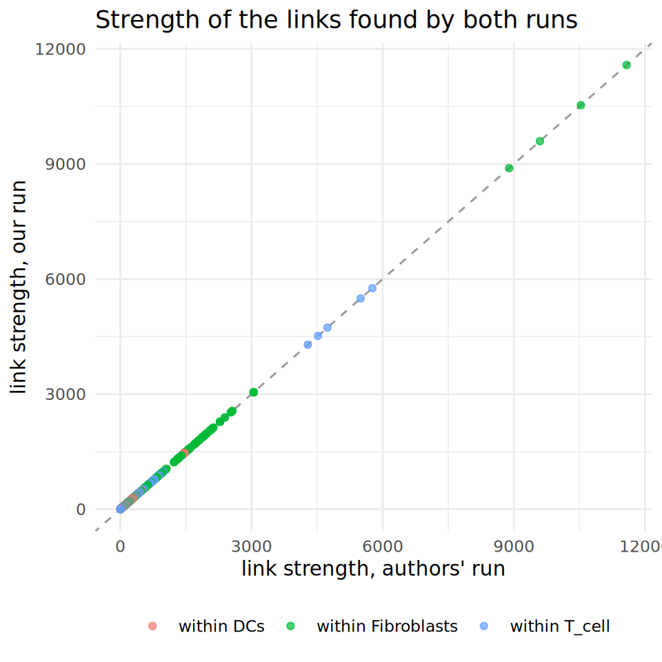

```r
ggplot(shared, aes(x = info_shifted_authors, y = info_shifted_ours, colour = category)) +
  geom_abline(linetype = "dashed", colour = "grey60") +
  geom_point(alpha = 0.7) +
  labs(x = "link strength, authors' run", y = "link strength, our run", colour = NULL,
       title = "Strength of the links found by both runs") +
  theme_minimal() +
  theme(legend.position = "bottom")
```

```r
shared_all <- comparison |> filter(found_in == "both")

table(authors = shared_all$orientation_authors, ours = shared_all$orientation_ours)
```

```
       ours
authors  -2   1   2   6
     -2 127   0   0   0
     1    0 440   0   0
     2    0   0 104   0
     6    0   0   0  44
```

```r
table(authors = shared_all$is_causal_authors, ours = shared_all$is_causal_ours)
```

```
       ours
authors   N   Y
      N 666   0
      Y   0  49
```

## 6. Strength of the L-R links

In case study 1 the server’s own output gave every L-R link the largest `info_shifted` of the network, and a later edit (April 2025) replaced these values. Which of the two does the case study 2 file contain?

```r
lr_strength <- function(edge_list) {
  edge_list |> filter(link_name(x, y) %in% lr_links) |> pull(info_shifted) |> unique()
}

max_gene_gene <- edges_ours |>
  filter(type == "P", !link_name(x, y) %in% lr_links) |>
  summarise(max(info_shifted)) |>
  pull()

list(authors = lr_strength(edges_authors), ours = lr_strength(edges_ours),
     largest_gene_gene_link = max_gene_gene)
```

```
$authors
[1] 11578.72

$ours
[1] 11578.72

$largest_gene_gene_link
[1] 11578.72
```

## 7. Do the paper’s statements still hold in our network?

The checks of notebook 03, section 6, repeated on our network.

```r
intracellular_ours <- edges_ours |>
  filter(type == "P", !link_name(x, y) %in% lr_links)

claims <- tribble(
  ~centre,              ~gene,
  "CXCL12_Fibroblasts", "DCN",
  "CXCL12_Fibroblasts", "APOD",
  "CXCL12_Fibroblasts", "CFD",
  "CXCR4_DCs",          "GPR183",
  "CXCR4_DCs",          "NR4A3",
  "CXCR4_DCs",          "VIM_DCs_DCs",
  "CXCR4_T_cell",       "FOS",
  "CXCR4_T_cell",       "JUNB"
)

claims |>
  mutate(distance_ours = map2_dbl(centre, gene, \(c, g) graph_distance(intracellular_ours, c)[g]))
```

```
# A tibble: 8 × 3
  centre             gene        distance_ours
  <chr>              <chr>               <dbl>
1 CXCL12_Fibroblasts DCN                     2
2 CXCL12_Fibroblasts APOD                    2
3 CXCL12_Fibroblasts CFD                     1
4 CXCR4_DCs          GPR183                  2
5 CXCR4_DCs          NR4A3                   1
6 CXCR4_DCs          VIM_DCs_DCs             2
7 CXCR4_T_cell       FOS                     2
8 CXCR4_T_cell       JUNB                    1
```

```r
edges_ours |>
  filter(type == "P", link_name(x, y) %in% link_name("CXCL12_Fibroblasts", c("CXCR4_DCs", "CXCR4_T_cell"))) |>
  select(x, y, infOrt, proba)
```

```
# A tibble: 2 × 4
  x                  y            infOrt proba
  <chr>              <chr>         <dbl> <chr>
1 CXCL12_Fibroblasts CXCR4_T_cell      2 0.5;1
2 CXCL12_Fibroblasts CXCR4_DCs         2 0.5;1
```

## What we learned

The conclusions below are written after reading the outputs above.

```r
# (names differ from the objects: inside tibble(), a new column would hide an object of the same name)
tibble(
  quantity = c("pairs examined", "pairs with the same decision", "retained links, authors", "retained links, ours",
               "links in both", "shared links with the same orientation", "genuine causations, authors",
               "genuine causations, ours"),
  value    = c(nrow(edges_authors), sum(all_pairs$type_authors == all_pairs$type_ours),
               nrow(links_authors), nrow(links_ours), sum(comparison$found_in == "both"),
               sum(shared_all$orientation_authors == shared_all$orientation_ours),
               sum(links_authors$is_causal == "Y"), sum(links_ours$is_causal == "Y"))
)
```

```
# A tibble: 8 × 2
  quantity                               value
  <chr>                                  <int>
1 pairs examined                          8458
2 pairs with the same decision            8458
3 retained links, authors                  715
4 retained links, ours                     715
5 links in both                            715
6 shared links with the same orientation   715
7 genuine causations, authors               49
8 genuine causations, ours                  49
```

The 15 pairs whose orientation probabilities differ as text (section 5) are not real differences. In 14 of them, our run writes the two variables in the opposite order (the metadata variable as `x`), so the two probabilities are swapped. In the last one, the values differ in the 15th decimal place:

```r
edges_authors |>
  transmute(link = link_name(x, y), x_authors = x, proba_authors = proba) |>
  inner_join(edges_ours |> transmute(link = link_name(x, y), x_ours = x, proba_ours = proba), by = "link") |>
  filter(proba_authors != proba_ours) |>
  mutate(same_order = x_authors == x_ours) |>
  count(same_order)
```

```
# A tibble: 2 × 2
  same_order     n
  <lgl>      <int>
1 FALSE         14
2 TRUE           1
```

**The network is reproduced exactly**, as for case study 1. With the authors’ three files and the server’s settings:

- the same decision (kept or rejected) for all 8,458 pairs examined;
- the same 715 retained links: 247 within fibroblasts, 200 within T cells, 225 within dendritic cells and the 43 L-R links;
- identical link strengths (differences below 10⁻¹²) and orientation probabilities;
- identical orientations and the same 49 genuine causations (rows of the edge list: a link of one of the 14 duplicated genes appears once per copy, and the two copies do not always agree, see notebook 07, section 5);
- confidence ratios slightly different (random shuffles with another seed, largest difference 0.008), with no effect on any decision.

Our run took 2.8 hours on one thread, close to the server’s 3 hours.

**L-R links.** Unlike case study 1, the authors’ file was not edited afterwards: every L-R link has the strength of the strongest gene–gene link (11,579), in both files. That strongest link is an artefact: it joins two identical copies of S100A6 in fibroblasts (notebook 03, section 7). Two identical columns share the maximum possible information, so MIIC links them as strongly as it can. Since the L-R links take the strength of the strongest link of the network, this artefact sets their value. With clean input (one column per gene), the artefact link would disappear, the maximum would be lower, and the L-R links would get a different strength.

**Bookkeeping.** As in notebook 02, our version of `miic` lists each L-R pair twice (86 rows instead of 43 pairs):

- a *placeholder* row written by the C++ core of `miic`, which only forces the pair into the network (strength 0, computed on 0 cells, no orientation);
- the *real* row added at the end by the `causalccc` branch (strength set to the network maximum, oriented ligand → receptor).

The authors’ file contains only the real rows, so the code that ran on the server did not keep the placeholders. They carry no information: we remove them, which leaves 43 rows as in the authors’ file. Otherwise every L-R link would be counted twice, once with strength 0.

**Paper’s statements.** All the checks of notebook 03 give the same distances in our network.

**What this means for the project.** For both case studies, the MIIC step is reproducible from the authors’ files. Any difference between the published networks and a rebuilt analysis can only come from how the input files were prepared, which notebook 05 examines for case study 2.